# Risk Factor Analysis

## Outcome Variable

**Outcome Variable:** ever_stunted

## Predictor Variables

**Intervention Variable:** anywast06

**Adjustment Set:**

- arm
- brthmon
- W_mage
- meducyrs
- hhwealth_quart
- month
- W_parity
- delta_W_mage
- delta_meducyrs
- delta_hhwealth_quart
- delta_month
- delta_W_parity

## Stratifying Variables

The analysis was stratified on these variable(s):

- agecat
- studyid
- country

## Data Summary

| agecat | studyid | country | anywast06 | ever_stunted | n_cell | n |
| --- | --- | --- | --- | --- | --- | --- |
| 0-24 months (no birth st.) | ki0047075b-MAL-ED | BANGLADESH | 0 | 0 | 75 | 217 |
| 0-24 months (no birth st.) | ki0047075b-MAL-ED | BANGLADESH | 0 | 1 | 93 | 217 |
| 0-24 months (no birth st.) | ki0047075b-MAL-ED | BANGLADESH | 1 | 0 | 28 | 217 |
| 0-24 months (no birth st.) | ki0047075b-MAL-ED | BANGLADESH | 1 | 1 | 21 | 217 |
| 0-24 months (no birth st.) | ki0047075b-MAL-ED | BRAZIL | 0 | 0 | 158 | 202 |
| 0-24 months (no birth st.) | ki0047075b-MAL-ED | BRAZIL | 0 | 1 | 30 | 202 |
| 0-24 months (no birth st.) | ki0047075b-MAL-ED | BRAZIL | 1 | 0 | 12 | 202 |
| 0-24 months (no birth st.) | ki0047075b-MAL-ED | BRAZIL | 1 | 1 | 2 | 202 |
| 0-24 months (no birth st.) | ki0047075b-MAL-ED | INDIA | 0 | 0 | 58 | 210 |
| 0-24 months (no birth st.) | ki0047075b-MAL-ED | INDIA | 0 | 1 | 84 | 210 |
| 0-24 months (no birth st.) | ki0047075b-MAL-ED | INDIA | 1 | 0 | 41 | 210 |
| 0-24 months (no birth st.) | ki0047075b-MAL-ED | INDIA | 1 | 1 | 27 | 210 |
| 0-24 months (no birth st.) | ki0047075b-MAL-ED | NEPAL | 0 | 0 | 128 | 211 |
| 0-24 months (no birth st.) | ki0047075b-MAL-ED | NEPAL | 0 | 1 | 44 | 211 |
| 0-24 months (no birth st.) | ki0047075b-MAL-ED | NEPAL | 1 | 0 | 28 | 211 |
| 0-24 months (no birth st.) | ki0047075b-MAL-ED | NEPAL | 1 | 1 | 11 | 211 |
| 0-24 months (no birth st.) | ki0047075b-MAL-ED | PERU | 0 | 0 | 112 | 266 |
| 0-24 months (no birth st.) | ki0047075b-MAL-ED | PERU | 0 | 1 | 146 | 266 |
| 0-24 months (no birth st.) | ki0047075b-MAL-ED | PERU | 1 | 0 | 3 | 266 |
| 0-24 months (no birth st.) | ki0047075b-MAL-ED | PERU | 1 | 1 | 5 | 266 |
| 0-24 months (no birth st.) | ki0047075b-MAL-ED | SOUTH AFRICA | 0 | 0 | 119 | 275 |
| 0-24 months (no birth st.) | ki0047075b-MAL-ED | SOUTH AFRICA | 0 | 1 | 124 | 275 |
| 0-24 months (no birth st.) | ki0047075b-MAL-ED | SOUTH AFRICA | 1 | 0 | 19 | 275 |
| 0-24 months (no birth st.) | ki0047075b-MAL-ED | SOUTH AFRICA | 1 | 1 | 13 | 275 |
| 0-24 months (no birth st.) | ki0047075b-MAL-ED | TANZANIA, UNITED REPUBLIC OF | 0 | 0 | 39 | 219 |
| 0-24 months (no birth st.) | ki0047075b-MAL-ED | TANZANIA, UNITED REPUBLIC OF | 0 | 1 | 170 | 219 |
| 0-24 months (no birth st.) | ki0047075b-MAL-ED | TANZANIA, UNITED REPUBLIC OF | 1 | 0 | 1 | 219 |
| 0-24 months (no birth st.) | ki0047075b-MAL-ED | TANZANIA, UNITED REPUBLIC OF | 1 | 1 | 9 | 219 |
| 0-24 months (no birth st.) | ki1000108-CMC-V-BCS-2002 | INDIA | 0 | 0 | 19 | 292 |
| 0-24 months (no birth st.) | ki1000108-CMC-V-BCS-2002 | INDIA | 0 | 1 | 120 | 292 |

[output cut: 186 more lines]

The following strata were considered:

- agecat: 0-24 months (no birth st.), studyid: ki0047075b-MAL-ED, country: BANGLADESH
- agecat: 0-24 months (no birth st.), studyid: ki0047075b-MAL-ED, country: BRAZIL
- agecat: 0-24 months (no birth st.), studyid: ki0047075b-MAL-ED, country: INDIA
- agecat: 0-24 months (no birth st.), studyid: ki0047075b-MAL-ED, country: NEPAL
- agecat: 0-24 months (no birth st.), studyid: ki0047075b-MAL-ED, country: PERU
- agecat: 0-24 months (no birth st.), studyid: ki0047075b-MAL-ED, country: SOUTH AFRICA
- agecat: 0-24 months (no birth st.), studyid: ki0047075b-MAL-ED, country: TANZANIA, UNITED REPUBLIC OF
- agecat: 0-24 months (no birth st.), studyid: ki1000108-CMC-V-BCS-2002, country: INDIA
- agecat: 0-24 months (no birth st.), studyid: ki1000108-IRC, country: INDIA
- agecat: 0-24 months (no birth st.), studyid: ki1000109-EE, country: PAKISTAN
- agecat: 0-24 months (no birth st.), studyid: ki1000109-ResPak, country: PAKISTAN
- agecat: 0-24 months (no birth st.), studyid: ki1017093b-PROVIDE, country: BANGLADESH
- agecat: 0-24 months (no birth st.), studyid: ki1066203-TanzaniaChild2, country: TANZANIA, UNITED REPUBLIC OF
- agecat: 0-24 months (no birth st.), studyid: ki1101329-Keneba, country: GAMBIA
- agecat: 0-24 months (no birth st.), studyid: ki1112895-Guatemala BSC, country: GUATEMALA
- agecat: 0-24 months (no birth st.), studyid: ki1113344-GMS-Nepal, country: NEPAL
- agecat: 0-24 months (no birth st.), studyid: ki1114097-CMIN, country: BANGLADESH
- agecat: 0-24 months (no birth st.), studyid: ki1114097-CONTENT, country: PERU
- agecat: 0-6 months (no birth st.), studyid: ki0047075b-MAL-ED, country: BANGLADESH
- agecat: 0-6 months (no birth st.), studyid: ki0047075b-MAL-ED, country: BRAZIL
- agecat: 0-6 months (no birth st.), studyid: ki0047075b-MAL-ED, country: INDIA
- agecat: 0-6 months (no birth st.), studyid: ki0047075b-MAL-ED, country: NEPAL
- agecat: 0-6 months (no birth st.), studyid: ki0047075b-MAL-ED, country: PERU
- agecat: 0-6 months (no birth st.), studyid: ki0047075b-MAL-ED, country: SOUTH AFRICA
- agecat: 0-6 months (no birth st.), studyid: ki0047075b-MAL-ED, country: TANZANIA, UNITED REPUBLIC OF
- agecat: 0-6 months (no birth st.), studyid: ki1000108-CMC-V-BCS-2002, country: INDIA
- agecat: 0-6 months (no birth st.), studyid: ki1000108-IRC, country: INDIA
- agecat: 0-6 months (no birth st.), studyid: ki1000109-EE, country: PAKISTAN
- agecat: 0-6 months (no birth st.), studyid: ki1000109-ResPak, country: PAKISTAN
- agecat: 0-6 months (no birth st.), studyid: ki1017093b-PROVIDE, country: BANGLADESH
- agecat: 0-6 months (no birth st.), studyid: ki1066203-TanzaniaChild2, country: TANZANIA, UNITED REPUBLIC OF
- agecat: 0-6 months (no birth st.), studyid: ki1101329-Keneba, country: GAMBIA
- agecat: 0-6 months (no birth st.), studyid: ki1112895-Guatemala BSC, country: GUATEMALA
- agecat: 0-6 months (no birth st.), studyid: ki1113344-GMS-Nepal, country: NEPAL
- agecat: 0-6 months (no birth st.), studyid: ki1114097-CMIN, country: BANGLADESH
- agecat: 0-6 months (no birth st.), studyid: ki1114097-CONTENT, country: PERU
- agecat: 6-24 months, studyid: ki0047075b-MAL-ED, country: BANGLADESH
- agecat: 6-24 months, studyid: ki0047075b-MAL-ED, country: BRAZIL
- agecat: 6-24 months, studyid: ki0047075b-MAL-ED, country: INDIA
- agecat: 6-24 months, studyid: ki0047075b-MAL-ED, country: NEPAL
- agecat: 6-24 months, studyid: ki0047075b-MAL-ED, country: PERU
- agecat: 6-24 months, studyid: ki0047075b-MAL-ED, country: SOUTH AFRICA
- agecat: 6-24 months, studyid: ki0047075b-MAL-ED, country: TANZANIA, UNITED REPUBLIC OF
- agecat: 6-24 months, studyid: ki1000108-CMC-V-BCS-2002, country: INDIA
- agecat: 6-24 months, studyid: ki1000108-IRC, country: INDIA
- agecat: 6-24 months, studyid: ki1000109-EE, country: PAKISTAN
- agecat: 6-24 months, studyid: ki1000109-ResPak, country: PAKISTAN
- agecat: 6-24 months, studyid: ki1017093b-PROVIDE, country: BANGLADESH
- agecat: 6-24 months, studyid: ki1066203-TanzaniaChild2, country: TANZANIA, UNITED REPUBLIC OF
- agecat: 6-24 months, studyid: ki1101329-Keneba, country: GAMBIA
- agecat: 6-24 months, studyid: ki1112895-Guatemala BSC, country: GUATEMALA
- agecat: 6-24 months, studyid: ki1113344-GMS-Nepal, country: NEPAL
- agecat: 6-24 months, studyid: ki1114097-CMIN, country: BANGLADESH
- agecat: 6-24 months, studyid: ki1114097-CONTENT, country: PERU

### Dropped Strata

Some strata were dropped due to rare outcomes:

- agecat: 0-24 months (no birth st.), studyid: ki0047075b-MAL-ED, country: BRAZIL
- agecat: 0-24 months (no birth st.), studyid: ki0047075b-MAL-ED, country: PERU
- agecat: 0-24 months (no birth st.), studyid: ki0047075b-MAL-ED, country: TANZANIA, UNITED REPUBLIC OF
- agecat: 0-24 months (no birth st.), studyid: ki1112895-Guatemala BSC, country: GUATEMALA
- agecat: 0-24 months (no birth st.), studyid: ki1114097-CONTENT, country: PERU
- agecat: 0-6 months (no birth st.), studyid: ki0047075b-MAL-ED, country: BRAZIL
- agecat: 0-6 months (no birth st.), studyid: ki0047075b-MAL-ED, country: NEPAL
- agecat: 0-6 months (no birth st.), studyid: ki0047075b-MAL-ED, country: PERU
- agecat: 0-6 months (no birth st.), studyid: ki0047075b-MAL-ED, country: TANZANIA, UNITED REPUBLIC OF
- agecat: 0-6 months (no birth st.), studyid: ki1112895-Guatemala BSC, country: GUATEMALA
- agecat: 0-6 months (no birth st.), studyid: ki1114097-CONTENT, country: PERU
- agecat: 6-24 months, studyid: ki0047075b-MAL-ED, country: BRAZIL
- agecat: 6-24 months, studyid: ki0047075b-MAL-ED, country: PERU
- agecat: 6-24 months, studyid: ki0047075b-MAL-ED, country: TANZANIA, UNITED REPUBLIC OF
- agecat: 6-24 months, studyid: ki1112895-Guatemala BSC, country: GUATEMALA
- agecat: 6-24 months, studyid: ki1114097-CONTENT, country: PERU

## Methods Detail

We’re interested in the causal parameters $E[Y_a]$ for all values of $a \in \mathcal{A}$. These parameters represent the mean outcome if, possibly contrary to fact, we intervened to set all units to have $A=a$. Under the randomization and positivity assumptions, these are identified by the statistical parameters $\psi_a=E_W[E_{Y|A,W}(Y|A=a,W)]$. In addition, we’re interested in the mean of $Y$, $E[Y]$ under no intervention (the observed mean). We will estimate these parameters by using SuperLearner to fit the relevant likelihood factors – $E_{Y|A,W}(Y|A=a,W)$ and $p(A=a|W)$, and then updating our likelihood fit using a joint TMLE.

For unadjusted analyses ($W=\{\}$), initial likelihoods were estimated using Lrnr_glm to estimate the simple $E(Y|A)$ and Lrnr_mean to estimate $p(A)$. For adjusted analyses, a small library containing Lrnr_glmnet, Lrnr_xgboost, and Lrnr_mean was used.

Having estimated these parameters, we will then use the delta method to estimate relative risks and attributable risks relative to a prespecified baseline level of $A$.

# Results Detail

## Results Plots

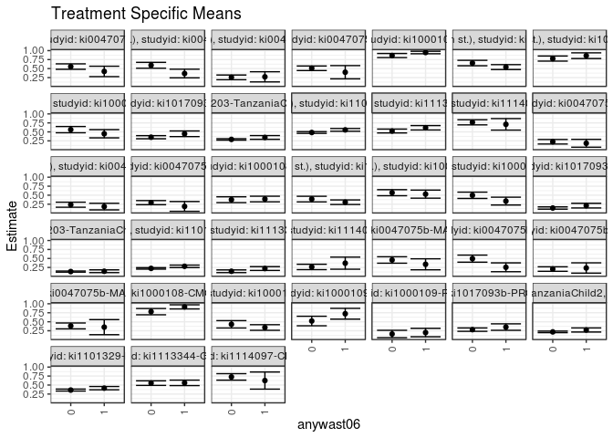

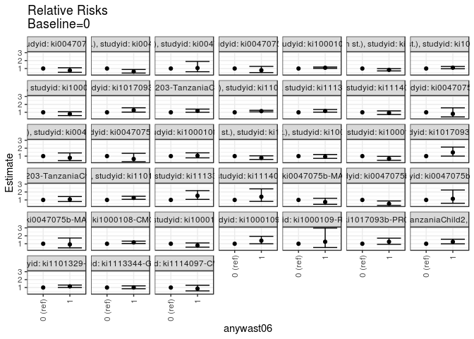

[figure not shown]

[figure not shown]

## Results Table

### Parameter: TSM

| agecat | studyid | country | intervention_level | baseline_level | estimate | ci_lower | ci_upper |
| --- | --- | --- | --- | --- | --- | --- | --- |
| 0-24 months (no birth st.) | ki0047075b-MAL-ED | BANGLADESH | 0 | NA | 0.5563122 | 0.4807505 | 0.6318739 |
| 0-24 months (no birth st.) | ki0047075b-MAL-ED | BANGLADESH | 1 | NA | 0.4217782 | 0.2771057 | 0.5664507 |
| 0-24 months (no birth st.) | ki0047075b-MAL-ED | INDIA | 0 | NA | 0.5920901 | 0.5107619 | 0.6734184 |
| 0-24 months (no birth st.) | ki0047075b-MAL-ED | INDIA | 1 | NA | 0.3631626 | 0.2426606 | 0.4836647 |
| 0-24 months (no birth st.) | ki0047075b-MAL-ED | NEPAL | 0 | NA | 0.2562650 | 0.1908927 | 0.3216373 |
| 0-24 months (no birth st.) | ki0047075b-MAL-ED | NEPAL | 1 | NA | 0.2714367 | 0.1303042 | 0.4125692 |
| 0-24 months (no birth st.) | ki0047075b-MAL-ED | SOUTH AFRICA | 0 | NA | 0.5090756 | 0.4459645 | 0.5721868 |
| 0-24 months (no birth st.) | ki0047075b-MAL-ED | SOUTH AFRICA | 1 | NA | 0.3991127 | 0.2153118 | 0.5829136 |
| 0-24 months (no birth st.) | ki1000108-CMC-V-BCS-2002 | INDIA | 0 | NA | 0.8633094 | 0.8061038 | 0.9205149 |
| 0-24 months (no birth st.) | ki1000108-CMC-V-BCS-2002 | INDIA | 1 | NA | 0.9477124 | 0.9123791 | 0.9830458 |
| 0-24 months (no birth st.) | ki1000108-IRC | INDIA | 0 | NA | 0.6542988 | 0.5788378 | 0.7297598 |
| 0-24 months (no birth st.) | ki1000108-IRC | INDIA | 1 | NA | 0.5418040 | 0.4738493 | 0.6097587 |
| 0-24 months (no birth st.) | ki1000109-EE | PAKISTAN | 0 | NA | 0.7787505 | 0.7082004 | 0.8493006 |
| 0-24 months (no birth st.) | ki1000109-EE | PAKISTAN | 1 | NA | 0.8589193 | 0.7799190 | 0.9379197 |
| 0-24 months (no birth st.) | ki1000109-ResPak | PAKISTAN | 0 | NA | 0.5623592 | 0.4752108 | 0.6495076 |
| 0-24 months (no birth st.) | ki1000109-ResPak | PAKISTAN | 1 | NA | 0.4484357 | 0.3341857 | 0.5626857 |
| 0-24 months (no birth st.) | ki1017093b-PROVIDE | BANGLADESH | 0 | NA | 0.3520296 | 0.3089272 | 0.3951321 |
| 0-24 months (no birth st.) | ki1017093b-PROVIDE | BANGLADESH | 1 | NA | 0.4476060 | 0.3691307 | 0.5260813 |
| 0-24 months (no birth st.) | ki1066203-TanzaniaChild2 | TANZANIA, UNITED REPUBLIC OF | 0 | NA | 0.2912056 | 0.2708557 | 0.3115554 |
| 0-24 months (no birth st.) | ki1066203-TanzaniaChild2 | TANZANIA, UNITED REPUBLIC OF | 1 | NA | 0.3457320 | 0.2934448 | 0.3980192 |
| 0-24 months (no birth st.) | ki1101329-Keneba | GAMBIA | 0 | NA | 0.4829001 | 0.4582780 | 0.5075222 |
| 0-24 months (no birth st.) | ki1101329-Keneba | GAMBIA | 1 | NA | 0.5560966 | 0.5182986 | 0.5938946 |
| 0-24 months (no birth st.) | ki1113344-GMS-Nepal | NEPAL | 0 | NA | 0.5242131 | 0.4707785 | 0.5776476 |
| 0-24 months (no birth st.) | ki1113344-GMS-Nepal | NEPAL | 1 | NA | 0.6145904 | 0.5531768 | 0.6760040 |
| 0-24 months (no birth st.) | ki1114097-CMIN | BANGLADESH | 0 | NA | 0.7664234 | 0.6953620 | 0.8374847 |
| 0-24 months (no birth st.) | ki1114097-CMIN | BANGLADESH | 1 | NA | 0.7096774 | 0.5494139 | 0.8699409 |
| 0-6 months (no birth st.) | ki0047075b-MAL-ED | BANGLADESH | 0 | NA | 0.2261905 | 0.1627815 | 0.2895994 |
| 0-6 months (no birth st.) | ki0047075b-MAL-ED | BANGLADESH | 1 | NA | 0.1836735 | 0.0750038 | 0.2923431 |
| 0-6 months (no birth st.) | ki0047075b-MAL-ED | INDIA | 0 | NA | 0.2349862 | 0.1647578 | 0.3052146 |
| 0-6 months (no birth st.) | ki0047075b-MAL-ED | INDIA | 1 | NA | 0.1832885 | 0.0914568 | 0.2751203 |
| 0-6 months (no birth st.) | ki0047075b-MAL-ED | SOUTH AFRICA | 0 | NA | 0.2921811 | 0.2348984 | 0.3494637 |
| 0-6 months (no birth st.) | ki0047075b-MAL-ED | SOUTH AFRICA | 1 | NA | 0.1875000 | 0.0520196 | 0.3229804 |
| 0-6 months (no birth st.) | ki1000108-CMC-V-BCS-2002 | INDIA | 0 | NA | 0.3741119 | 0.2930236 | 0.4552003 |
| 0-6 months (no birth st.) | ki1000108-CMC-V-BCS-2002 | INDIA | 1 | NA | 0.3934621 | 0.3156524 | 0.4712718 |
| 0-6 months (no birth st.) | ki1000108-IRC | INDIA | 0 | NA | 0.3916795 | 0.3135902 | 0.4697689 |
| 0-6 months (no birth st.) | ki1000108-IRC | INDIA | 1 | NA | 0.3047041 | 0.2416571 | 0.3677512 |
| 0-6 months (no birth st.) | ki1000109-EE | PAKISTAN | 0 | NA | 0.5689078 | 0.4848140 | 0.6530015 |
| 0-6 months (no birth st.) | ki1000109-EE | PAKISTAN | 1 | NA | 0.5298306 | 0.4173323 | 0.6423289 |
| 0-6 months (no birth st.) | ki1000109-ResPak | PAKISTAN | 0 | NA | 0.4971249 | 0.4093572 | 0.5848926 |
| 0-6 months (no birth st.) | ki1000109-ResPak | PAKISTAN | 1 | NA | 0.3353025 | 0.2268677 | 0.4437373 |
| 0-6 months (no birth st.) | ki1017093b-PROVIDE | BANGLADESH | 0 | NA | 0.1430061 | 0.1114649 | 0.1745473 |
| 0-6 months (no birth st.) | ki1017093b-PROVIDE | BANGLADESH | 1 | NA | 0.2093817 | 0.1447278 | 0.2740356 |
| 0-6 months (no birth st.) | ki1066203-TanzaniaChild2 | TANZANIA, UNITED REPUBLIC OF | 0 | NA | 0.1356184 | 0.1202828 | 0.1509540 |
| 0-6 months (no birth st.) | ki1066203-TanzaniaChild2 | TANZANIA, UNITED REPUBLIC OF | 1 | NA | 0.1446122 | 0.1059148 | 0.1833095 |
| 0-6 months (no birth st.) | ki1101329-Keneba | GAMBIA | 0 | NA | 0.2242697 | 0.2036827 | 0.2448566 |
| 0-6 months (no birth st.) | ki1101329-Keneba | GAMBIA | 1 | NA | 0.2820745 | 0.2475221 | 0.3166269 |
| 0-6 months (no birth st.) | ki1113344-GMS-Nepal | NEPAL | 0 | NA | 0.1441814 | 0.1068688 | 0.1814941 |
| 0-6 months (no birth st.) | ki1113344-GMS-Nepal | NEPAL | 1 | NA | 0.2201046 | 0.1672578 | 0.2729515 |
| 0-6 months (no birth st.) | ki1114097-CMIN | BANGLADESH | 0 | NA | 0.2640338 | 0.1893412 | 0.3387264 |
| 0-6 months (no birth st.) | ki1114097-CMIN | BANGLADESH | 1 | NA | 0.3692172 | 0.2006717 | 0.5377627 |
| 6-24 months | ki0047075b-MAL-ED | BANGLADESH | 0 | NA | 0.4580912 | 0.3688336 | 0.5473488 |
| 6-24 months | ki0047075b-MAL-ED | BANGLADESH | 1 | NA | 0.3377153 | 0.1845376 | 0.4908930 |
| 6-24 months | ki0047075b-MAL-ED | INDIA | 0 | NA | 0.4948919 | 0.3967502 | 0.5930337 |
| 6-24 months | ki0047075b-MAL-ED | INDIA | 1 | NA | 0.2549644 | 0.1321122 | 0.3778166 |
| 6-24 months | ki0047075b-MAL-ED | NEPAL | 0 | NA | 0.2062500 | 0.1433937 | 0.2691063 |
| 6-24 months | ki0047075b-MAL-ED | NEPAL | 1 | NA | 0.2352941 | 0.0923443 | 0.3782439 |
| 6-24 months | ki0047075b-MAL-ED | SOUTH AFRICA | 0 | NA | 0.3840580 | 0.3026521 | 0.4654638 |
| 6-24 months | ki0047075b-MAL-ED | SOUTH AFRICA | 1 | NA | 0.3500000 | 0.1402980 | 0.5597020 |
| 6-24 months | ki1000108-CMC-V-BCS-2002 | INDIA | 0 | NA | 0.7816092 | 0.6945509 | 0.8686675 |
| 6-24 months | ki1000108-CMC-V-BCS-2002 | INDIA | 1 | NA | 0.9139785 | 0.8568322 | 0.9711248 |
| 6-24 months | ki1000108-IRC | INDIA | 0 | NA | 0.4297013 | 0.3274536 | 0.5319491 |
| 6-24 months | ki1000108-IRC | INDIA | 1 | NA | 0.3403523 | 0.2621920 | 0.4185126 |
| 6-24 months | ki1000109-EE | PAKISTAN | 0 | NA | 0.5209484 | 0.3879742 | 0.6539227 |
| 6-24 months | ki1000109-EE | PAKISTAN | 1 | NA | 0.7230608 | 0.5730270 | 0.8730946 |
| 6-24 months | ki1000109-ResPak | PAKISTAN | 0 | NA | 0.1600000 | 0.0578448 | 0.2621552 |
| 6-24 months | ki1000109-ResPak | PAKISTAN | 1 | NA | 0.2000000 | 0.0825103 | 0.3174897 |
| 6-24 months | ki1017093b-PROVIDE | BANGLADESH | 0 | NA | 0.2806189 | 0.2336704 | 0.3275673 |
| 6-24 months | ki1017093b-PROVIDE | BANGLADESH | 1 | NA | 0.3521235 | 0.2623506 | 0.4418963 |
| 6-24 months | ki1066203-TanzaniaChild2 | TANZANIA, UNITED REPUBLIC OF | 0 | NA | 0.2181491 | 0.1962200 | 0.2400781 |
| 6-24 months | ki1066203-TanzaniaChild2 | TANZANIA, UNITED REPUBLIC OF | 1 | NA | 0.2712509 | 0.2143065 | 0.3281952 |
| 6-24 months | ki1101329-Keneba | GAMBIA | 0 | NA | 0.3603824 | 0.3323797 | 0.3883851 |
| 6-24 months | ki1101329-Keneba | GAMBIA | 1 | NA | 0.4135704 | 0.3677696 | 0.4593711 |
| 6-24 months | ki1113344-GMS-Nepal | NEPAL | 0 | NA | 0.5536718 | 0.4896504 | 0.6176933 |
| 6-24 months | ki1113344-GMS-Nepal | NEPAL | 1 | NA | 0.5612699 | 0.4852758 | 0.6372641 |
| 6-24 months | ki1114097-CMIN | BANGLADESH | 0 | NA | 0.7263158 | 0.6362543 | 0.8163773 |
| 6-24 months | ki1114097-CMIN | BANGLADESH | 1 | NA | 0.6250000 | 0.3867083 | 0.8632917 |

### Parameter: E(Y)

| agecat | studyid | country | intervention_level | baseline_level | estimate | ci_lower | ci_upper |
| --- | --- | --- | --- | --- | --- | --- | --- |
| 0-24 months (no birth st.) | ki0047075b-MAL-ED | BANGLADESH | NA | NA | 0.5253456 | 0.4587520 | 0.5919392 |
| 0-24 months (no birth st.) | ki0047075b-MAL-ED | INDIA | NA | NA | 0.5285714 | 0.4608954 | 0.5962474 |
| 0-24 months (no birth st.) | ki0047075b-MAL-ED | NEPAL | NA | NA | 0.2606635 | 0.2012891 | 0.3200380 |
| 0-24 months (no birth st.) | ki0047075b-MAL-ED | SOUTH AFRICA | NA | NA | 0.4981818 | 0.4389793 | 0.5573843 |
| 0-24 months (no birth st.) | ki1000108-CMC-V-BCS-2002 | INDIA | NA | NA | 0.9075342 | 0.8742512 | 0.9408173 |
| 0-24 months (no birth st.) | ki1000108-IRC | INDIA | NA | NA | 0.5916667 | 0.5408218 | 0.6425115 |
| 0-24 months (no birth st.) | ki1000109-EE | PAKISTAN | NA | NA | 0.8075117 | 0.7544408 | 0.8605827 |
| 0-24 months (no birth st.) | ki1000109-ResPak | PAKISTAN | NA | NA | 0.5198020 | 0.4507336 | 0.5888704 |
| 0-24 months (no birth st.) | ki1017093b-PROVIDE | BANGLADESH | NA | NA | 0.3759874 | 0.3382238 | 0.4137509 |
| 0-24 months (no birth st.) | ki1066203-TanzaniaChild2 | TANZANIA, UNITED REPUBLIC OF | NA | NA | 0.2988814 | 0.2798990 | 0.3178639 |
| 0-24 months (no birth st.) | ki1101329-Keneba | GAMBIA | NA | NA | 0.5044763 | 0.4837388 | 0.5252138 |
| 0-24 months (no birth st.) | ki1113344-GMS-Nepal | NEPAL | NA | NA | 0.5625000 | 0.5219525 | 0.6030475 |
| 0-24 months (no birth st.) | ki1114097-CMIN | BANGLADESH | NA | NA | 0.7559524 | 0.6908084 | 0.8210964 |
| 0-6 months (no birth st.) | ki0047075b-MAL-ED | BANGLADESH | NA | NA | 0.2165899 | 0.1616567 | 0.2715231 |
| 0-6 months (no birth st.) | ki0047075b-MAL-ED | INDIA | NA | NA | 0.2190476 | 0.1629743 | 0.2751210 |
| 0-6 months (no birth st.) | ki0047075b-MAL-ED | SOUTH AFRICA | NA | NA | 0.2800000 | 0.2268359 | 0.3331641 |
| 0-6 months (no birth st.) | ki1000108-CMC-V-BCS-2002 | INDIA | NA | NA | 0.3835616 | 0.3276935 | 0.4394298 |
| 0-6 months (no birth st.) | ki1000108-IRC | INDIA | NA | NA | 0.3444444 | 0.2952897 | 0.3935992 |
| 0-6 months (no birth st.) | ki1000109-EE | PAKISTAN | NA | NA | 0.5539906 | 0.4870787 | 0.6209025 |
| 0-6 months (no birth st.) | ki1000109-ResPak | PAKISTAN | NA | NA | 0.4356436 | 0.3670959 | 0.5041912 |
| 0-6 months (no birth st.) | ki1017093b-PROVIDE | BANGLADESH | NA | NA | 0.1595577 | 0.1310079 | 0.1881074 |
| 0-6 months (no birth st.) | ki1066203-TanzaniaChild2 | TANZANIA, UNITED REPUBLIC OF | NA | NA | 0.1369128 | 0.1226581 | 0.1511674 |
| 0-6 months (no birth st.) | ki1101329-Keneba | GAMBIA | NA | NA | 0.2412713 | 0.2235253 | 0.2590172 |
| 0-6 months (no birth st.) | ki1113344-GMS-Nepal | NEPAL | NA | NA | 0.1736111 | 0.1426515 | 0.2045707 |
| 0-6 months (no birth st.) | ki1114097-CMIN | BANGLADESH | NA | NA | 0.2857143 | 0.2171983 | 0.3542303 |
| 6-24 months | ki0047075b-MAL-ED | BANGLADESH | NA | NA | 0.4240506 | 0.3467471 | 0.5013542 |
| 6-24 months | ki0047075b-MAL-ED | INDIA | NA | NA | 0.4220779 | 0.3438191 | 0.5003367 |
| 6-24 months | ki0047075b-MAL-ED | NEPAL | NA | NA | 0.2113402 | 0.1537425 | 0.2689379 |
| 6-24 months | ki0047075b-MAL-ED | SOUTH AFRICA | NA | NA | 0.3797468 | 0.3038314 | 0.4556622 |
| 6-24 months | ki1000108-CMC-V-BCS-2002 | INDIA | NA | NA | 0.8500000 | 0.7976910 | 0.9023090 |
| 6-24 months | ki1000108-IRC | INDIA | NA | NA | 0.3771186 | 0.3151523 | 0.4390850 |
| 6-24 months | ki1000109-EE | PAKISTAN | NA | NA | 0.5806452 | 0.4798127 | 0.6814776 |
| 6-24 months | ki1000109-ResPak | PAKISTAN | NA | NA | 0.1789474 | 0.1014597 | 0.2564350 |
| 6-24 months | ki1017093b-PROVIDE | BANGLADESH | NA | NA | 0.3004386 | 0.2583143 | 0.3425629 |
| 6-24 months | ki1066203-TanzaniaChild2 | TANZANIA, UNITED REPUBLIC OF | NA | NA | 0.2259675 | 0.2054816 | 0.2464534 |
| 6-24 months | ki1101329-Keneba | GAMBIA | NA | NA | 0.3752393 | 0.3512585 | 0.3992201 |
| 6-24 months | ki1113344-GMS-Nepal | NEPAL | NA | NA | 0.5642317 | 0.5153938 | 0.6130696 |
| 6-24 months | ki1114097-CMIN | BANGLADESH | NA | NA | 0.7117117 | 0.6270636 | 0.7963598 |

### Parameter: RR

| agecat | studyid | country | intervention_level | baseline_level | estimate | ci_lower | ci_upper |
| --- | --- | --- | --- | --- | --- | --- | --- |
| 0-24 months (no birth st.) | ki0047075b-MAL-ED | BANGLADESH | 0 | 0 | 1.0000000 | 1.0000000 | 1.0000000 |
| 0-24 months (no birth st.) | ki0047075b-MAL-ED | BANGLADESH | 1 | 0 | 0.7581681 | 0.5246933 | 1.0955331 |
| 0-24 months (no birth st.) | ki0047075b-MAL-ED | INDIA | 0 | 0 | 1.0000000 | 1.0000000 | 1.0000000 |
| 0-24 months (no birth st.) | ki0047075b-MAL-ED | INDIA | 1 | 0 | 0.6133570 | 0.4278179 | 0.8793620 |
| 0-24 months (no birth st.) | ki0047075b-MAL-ED | NEPAL | 0 | 0 | 1.0000000 | 1.0000000 | 1.0000000 |
| 0-24 months (no birth st.) | ki0047075b-MAL-ED | NEPAL | 1 | 0 | 1.0592032 | 0.5940673 | 1.8885257 |
| 0-24 months (no birth st.) | ki0047075b-MAL-ED | SOUTH AFRICA | 0 | 0 | 1.0000000 | 1.0000000 | 1.0000000 |
| 0-24 months (no birth st.) | ki0047075b-MAL-ED | SOUTH AFRICA | 1 | 0 | 0.7839949 | 0.4864376 | 1.2635702 |
| 0-24 months (no birth st.) | ki1000108-CMC-V-BCS-2002 | INDIA | 0 | 0 | 1.0000000 | 1.0000000 | 1.0000000 |
| 0-24 months (no birth st.) | ki1000108-CMC-V-BCS-2002 | INDIA | 1 | 0 | 1.0977669 | 1.0173960 | 1.1844868 |
| 0-24 months (no birth st.) | ki1000108-IRC | INDIA | 0 | 0 | 1.0000000 | 1.0000000 | 1.0000000 |
| 0-24 months (no birth st.) | ki1000108-IRC | INDIA | 1 | 0 | 0.8280681 | 0.6986180 | 0.9815045 |
| 0-24 months (no birth st.) | ki1000109-EE | PAKISTAN | 0 | 0 | 1.0000000 | 1.0000000 | 1.0000000 |
| 0-24 months (no birth st.) | ki1000109-EE | PAKISTAN | 1 | 0 | 1.1029455 | 0.9690775 | 1.2553060 |
| 0-24 months (no birth st.) | ki1000109-ResPak | PAKISTAN | 0 | 0 | 1.0000000 | 1.0000000 | 1.0000000 |
| 0-24 months (no birth st.) | ki1000109-ResPak | PAKISTAN | 1 | 0 | 0.7974185 | 0.5918577 | 1.0743737 |
| 0-24 months (no birth st.) | ki1017093b-PROVIDE | BANGLADESH | 0 | 0 | 1.0000000 | 1.0000000 | 1.0000000 |
| 0-24 months (no birth st.) | ki1017093b-PROVIDE | BANGLADESH | 1 | 0 | 1.2715009 | 1.0269953 | 1.5742181 |
| 0-24 months (no birth st.) | ki1066203-TanzaniaChild2 | TANZANIA, UNITED REPUBLIC OF | 0 | 0 | 1.0000000 | 1.0000000 | 1.0000000 |
| 0-24 months (no birth st.) | ki1066203-TanzaniaChild2 | TANZANIA, UNITED REPUBLIC OF | 1 | 0 | 1.1872438 | 1.0050099 | 1.4025213 |
| 0-24 months (no birth st.) | ki1101329-Keneba | GAMBIA | 0 | 0 | 1.0000000 | 1.0000000 | 1.0000000 |
| 0-24 months (no birth st.) | ki1101329-Keneba | GAMBIA | 1 | 0 | 1.1515769 | 1.0582732 | 1.2531068 |
| 0-24 months (no birth st.) | ki1113344-GMS-Nepal | NEPAL | 0 | 0 | 1.0000000 | 1.0000000 | 1.0000000 |
| 0-24 months (no birth st.) | ki1113344-GMS-Nepal | NEPAL | 1 | 0 | 1.1724057 | 1.0163835 | 1.3523784 |
| 0-24 months (no birth st.) | ki1114097-CMIN | BANGLADESH | 0 | 0 | 1.0000000 | 1.0000000 | 1.0000000 |
| 0-24 months (no birth st.) | ki1114097-CMIN | BANGLADESH | 1 | 0 | 0.9259601 | 0.7253921 | 1.1819842 |
| 0-6 months (no birth st.) | ki0047075b-MAL-ED | BANGLADESH | 0 | 0 | 1.0000000 | 1.0000000 | 1.0000000 |
| 0-6 months (no birth st.) | ki0047075b-MAL-ED | BANGLADESH | 1 | 0 | 0.8120301 | 0.4219291 | 1.5628047 |
| 0-6 months (no birth st.) | ki0047075b-MAL-ED | INDIA | 0 | 0 | 1.0000000 | 1.0000000 | 1.0000000 |
| 0-6 months (no birth st.) | ki0047075b-MAL-ED | INDIA | 1 | 0 | 0.7799972 | 0.4341804 | 1.4012508 |
| 0-6 months (no birth st.) | ki0047075b-MAL-ED | SOUTH AFRICA | 0 | 0 | 1.0000000 | 1.0000000 | 1.0000000 |
| 0-6 months (no birth st.) | ki0047075b-MAL-ED | SOUTH AFRICA | 1 | 0 | 0.6417254 | 0.3035278 | 1.3567502 |
| 0-6 months (no birth st.) | ki1000108-CMC-V-BCS-2002 | INDIA | 0 | 0 | 1.0000000 | 1.0000000 | 1.0000000 |
| 0-6 months (no birth st.) | ki1000108-CMC-V-BCS-2002 | INDIA | 1 | 0 | 1.0517231 | 0.7837921 | 1.4112433 |
| 0-6 months (no birth st.) | ki1000108-IRC | INDIA | 0 | 0 | 1.0000000 | 1.0000000 | 1.0000000 |
| 0-6 months (no birth st.) | ki1000108-IRC | INDIA | 1 | 0 | 0.7779425 | 0.5832874 | 1.0375582 |
| 0-6 months (no birth st.) | ki1000109-EE | PAKISTAN | 0 | 0 | 1.0000000 | 1.0000000 | 1.0000000 |
| 0-6 months (no birth st.) | ki1000109-EE | PAKISTAN | 1 | 0 | 0.9313119 | 0.7186784 | 1.2068568 |
| 0-6 months (no birth st.) | ki1000109-ResPak | PAKISTAN | 0 | 0 | 1.0000000 | 1.0000000 | 1.0000000 |
| 0-6 months (no birth st.) | ki1000109-ResPak | PAKISTAN | 1 | 0 | 0.6744833 | 0.4666646 | 0.9748495 |
| 0-6 months (no birth st.) | ki1017093b-PROVIDE | BANGLADESH | 0 | 0 | 1.0000000 | 1.0000000 | 1.0000000 |
| 0-6 months (no birth st.) | ki1017093b-PROVIDE | BANGLADESH | 1 | 0 | 1.4641452 | 1.0014662 | 2.1405827 |
| 0-6 months (no birth st.) | ki1066203-TanzaniaChild2 | TANZANIA, UNITED REPUBLIC OF | 0 | 0 | 1.0000000 | 1.0000000 | 1.0000000 |
| 0-6 months (no birth st.) | ki1066203-TanzaniaChild2 | TANZANIA, UNITED REPUBLIC OF | 1 | 0 | 1.0663166 | 0.7974664 | 1.4258045 |
| 0-6 months (no birth st.) | ki1101329-Keneba | GAMBIA | 0 | 0 | 1.0000000 | 1.0000000 | 1.0000000 |
| 0-6 months (no birth st.) | ki1101329-Keneba | GAMBIA | 1 | 0 | 1.2577472 | 1.0794321 | 1.4655189 |
| 0-6 months (no birth st.) | ki1113344-GMS-Nepal | NEPAL | 0 | 0 | 1.0000000 | 1.0000000 | 1.0000000 |
| 0-6 months (no birth st.) | ki1113344-GMS-Nepal | NEPAL | 1 | 0 | 1.5265809 | 1.0720007 | 2.1739251 |
| 0-6 months (no birth st.) | ki1114097-CMIN | BANGLADESH | 0 | 0 | 1.0000000 | 1.0000000 | 1.0000000 |
| 0-6 months (no birth st.) | ki1114097-CMIN | BANGLADESH | 1 | 0 | 1.3983707 | 0.8171106 | 2.3931162 |
| 6-24 months | ki0047075b-MAL-ED | BANGLADESH | 0 | 0 | 1.0000000 | 1.0000000 | 1.0000000 |
| 6-24 months | ki0047075b-MAL-ED | BANGLADESH | 1 | 0 | 0.7372228 | 0.4499214 | 1.2079830 |
| 6-24 months | ki0047075b-MAL-ED | INDIA | 0 | 0 | 1.0000000 | 1.0000000 | 1.0000000 |
| 6-24 months | ki0047075b-MAL-ED | INDIA | 1 | 0 | 0.5151921 | 0.3056795 | 0.8683044 |
| 6-24 months | ki0047075b-MAL-ED | NEPAL | 0 | 0 | 1.0000000 | 1.0000000 | 1.0000000 |
| 6-24 months | ki0047075b-MAL-ED | NEPAL | 1 | 0 | 1.1408200 | 0.5781380 | 2.2511409 |
| 6-24 months | ki0047075b-MAL-ED | SOUTH AFRICA | 0 | 0 | 1.0000000 | 1.0000000 | 1.0000000 |
| 6-24 months | ki0047075b-MAL-ED | SOUTH AFRICA | 1 | 0 | 0.9113208 | 0.4826821 | 1.7206057 |
| 6-24 months | ki1000108-CMC-V-BCS-2002 | INDIA | 0 | 0 | 1.0000000 | 1.0000000 | 1.0000000 |
| 6-24 months | ki1000108-CMC-V-BCS-2002 | INDIA | 1 | 0 | 1.1693548 | 1.0291360 | 1.3286784 |
| 6-24 months | ki1000108-IRC | INDIA | 0 | 0 | 1.0000000 | 1.0000000 | 1.0000000 |
| 6-24 months | ki1000108-IRC | INDIA | 1 | 0 | 0.7920671 | 0.5687981 | 1.1029754 |
| 6-24 months | ki1000109-EE | PAKISTAN | 0 | 0 | 1.0000000 | 1.0000000 | 1.0000000 |
| 6-24 months | ki1000109-EE | PAKISTAN | 1 | 0 | 1.3879700 | 0.9973156 | 1.9316460 |
| 6-24 months | ki1000109-ResPak | PAKISTAN | 0 | 0 | 1.0000000 | 1.0000000 | 1.0000000 |
| 6-24 months | ki1000109-ResPak | PAKISTAN | 1 | 0 | 1.2500000 | 0.5249448 | 2.9765036 |
| 6-24 months | ki1017093b-PROVIDE | BANGLADESH | 0 | 0 | 1.0000000 | 1.0000000 | 1.0000000 |
| 6-24 months | ki1017093b-PROVIDE | BANGLADESH | 1 | 0 | 1.2548104 | 0.9253554 | 1.7015614 |
| 6-24 months | ki1066203-TanzaniaChild2 | TANZANIA, UNITED REPUBLIC OF | 0 | 0 | 1.0000000 | 1.0000000 | 1.0000000 |
| 6-24 months | ki1066203-TanzaniaChild2 | TANZANIA, UNITED REPUBLIC OF | 1 | 0 | 1.2434198 | 0.9851516 | 1.5693958 |
| 6-24 months | ki1101329-Keneba | GAMBIA | 0 | 0 | 1.0000000 | 1.0000000 | 1.0000000 |
| 6-24 months | ki1101329-Keneba | GAMBIA | 1 | 0 | 1.1475876 | 1.0028064 | 1.3132718 |
| 6-24 months | ki1113344-GMS-Nepal | NEPAL | 0 | 0 | 1.0000000 | 1.0000000 | 1.0000000 |
| 6-24 months | ki1113344-GMS-Nepal | NEPAL | 1 | 0 | 1.0137230 | 0.8480479 | 1.2117646 |
| 6-24 months | ki1114097-CMIN | BANGLADESH | 0 | 0 | 1.0000000 | 1.0000000 | 1.0000000 |
| 6-24 months | ki1114097-CMIN | BANGLADESH | 1 | 0 | 0.8605072 | 0.5762828 | 1.2849121 |

### Parameter: PAR

| agecat | studyid | country | intervention_level | baseline_level | estimate | ci_lower | ci_upper |
| --- | --- | --- | --- | --- | --- | --- | --- |
| 0-24 months (no birth st.) | ki0047075b-MAL-ED | BANGLADESH | 0 | NA | -0.0309666 | -0.0672876 | 0.0053544 |
| 0-24 months (no birth st.) | ki0047075b-MAL-ED | INDIA | 0 | NA | -0.0635187 | -0.1114884 | -0.0155491 |
| 0-24 months (no birth st.) | ki0047075b-MAL-ED | NEPAL | 0 | NA | 0.0043985 | -0.0244735 | 0.0332705 |
| 0-24 months (no birth st.) | ki0047075b-MAL-ED | SOUTH AFRICA | 0 | NA | -0.0108938 | -0.0326022 | 0.0108146 |
| 0-24 months (no birth st.) | ki1000108-CMC-V-BCS-2002 | INDIA | 0 | NA | 0.0442249 | 0.0086628 | 0.0797870 |
| 0-24 months (no birth st.) | ki1000108-IRC | INDIA | 0 | NA | -0.0626322 | -0.1214114 | -0.0038529 |
| 0-24 months (no birth st.) | ki1000109-EE | PAKISTAN | 0 | NA | 0.0287613 | -0.0102873 | 0.0678098 |
| 0-24 months (no birth st.) | ki1000109-ResPak | PAKISTAN | 0 | NA | -0.0425573 | -0.0964859 | 0.0113714 |
| 0-24 months (no birth st.) | ki1017093b-PROVIDE | BANGLADESH | 0 | NA | 0.0239577 | 0.0015111 | 0.0464044 |
| 0-24 months (no birth st.) | ki1066203-TanzaniaChild2 | TANZANIA, UNITED REPUBLIC OF | 0 | NA | 0.0076759 | -0.0003613 | 0.0157130 |
| 0-24 months (no birth st.) | ki1101329-Keneba | GAMBIA | 0 | NA | 0.0215762 | 0.0083344 | 0.0348179 |
| 0-24 months (no birth st.) | ki1113344-GMS-Nepal | NEPAL | 0 | NA | 0.0382869 | 0.0045103 | 0.0720636 |
| 0-24 months (no birth st.) | ki1114097-CMIN | BANGLADESH | 0 | NA | -0.0104710 | -0.0429919 | 0.0220500 |
| 0-6 months (no birth st.) | ki0047075b-MAL-ED | BANGLADESH | 0 | NA | -0.0096006 | -0.0381095 | 0.0189083 |
| 0-6 months (no birth st.) | ki0047075b-MAL-ED | INDIA | 0 | NA | -0.0159386 | -0.0548888 | 0.0230117 |
| 0-6 months (no birth st.) | ki0047075b-MAL-ED | SOUTH AFRICA | 0 | NA | -0.0121811 | -0.0297527 | 0.0053906 |
| 0-6 months (no birth st.) | ki1000108-CMC-V-BCS-2002 | INDIA | 0 | NA | 0.0094497 | -0.0495488 | 0.0684483 |
| 0-6 months (no birth st.) | ki1000108-IRC | INDIA | 0 | NA | -0.0472351 | -0.1054778 | 0.0110077 |
| 0-6 months (no birth st.) | ki1000109-EE | PAKISTAN | 0 | NA | -0.0149172 | -0.0662949 | 0.0364605 |
| 0-6 months (no birth st.) | ki1000109-ResPak | PAKISTAN | 0 | NA | -0.0614814 | -0.1142968 | -0.0086659 |
| 0-6 months (no birth st.) | ki1017093b-PROVIDE | BANGLADESH | 0 | NA | 0.0165516 | -0.0013483 | 0.0344515 |
| 0-6 months (no birth st.) | ki1066203-TanzaniaChild2 | TANZANIA, UNITED REPUBLIC OF | 0 | NA | 0.0012943 | -0.0046309 | 0.0072195 |
| 0-6 months (no birth st.) | ki1101329-Keneba | GAMBIA | 0 | NA | 0.0170016 | 0.0051628 | 0.0288404 |
| 0-6 months (no birth st.) | ki1113344-GMS-Nepal | NEPAL | 0 | NA | 0.0294297 | 0.0029049 | 0.0559545 |
| 0-6 months (no birth st.) | ki1114097-CMIN | BANGLADESH | 0 | NA | 0.0216805 | -0.0142730 | 0.0576340 |
| 6-24 months | ki0047075b-MAL-ED | BANGLADESH | 0 | NA | -0.0340406 | -0.0765863 | 0.0085051 |
| 6-24 months | ki0047075b-MAL-ED | INDIA | 0 | NA | -0.0728140 | -0.1287293 | -0.0168987 |
| 6-24 months | ki0047075b-MAL-ED | NEPAL | 0 | NA | 0.0050902 | -0.0223221 | 0.0325025 |
| 6-24 months | ki0047075b-MAL-ED | SOUTH AFRICA | 0 | NA | -0.0043111 | -0.0328407 | 0.0242184 |
| 6-24 months | ki1000108-CMC-V-BCS-2002 | INDIA | 0 | NA | 0.0683908 | 0.0137202 | 0.1230614 |
| 6-24 months | ki1000108-IRC | INDIA | 0 | NA | -0.0525827 | -0.1314367 | 0.0262713 |
| 6-24 months | ki1000109-EE | PAKISTAN | 0 | NA | 0.0596967 | -0.0234917 | 0.1428851 |
| 6-24 months | ki1000109-ResPak | PAKISTAN | 0 | NA | 0.0189474 | -0.0549112 | 0.0928059 |
| 6-24 months | ki1017093b-PROVIDE | BANGLADESH | 0 | NA | 0.0198197 | -0.0040690 | 0.0437085 |
| 6-24 months | ki1066203-TanzaniaChild2 | TANZANIA, UNITED REPUBLIC OF | 0 | NA | 0.0078185 | -0.0012128 | 0.0168497 |
| 6-24 months | ki1101329-Keneba | GAMBIA | 0 | NA | 0.0148569 | -0.0003281 | 0.0300419 |
| 6-24 months | ki1113344-GMS-Nepal | NEPAL | 0 | NA | 0.0105599 | -0.0306737 | 0.0517935 |
| 6-24 months | ki1114097-CMIN | BANGLADESH | 0 | NA | -0.0146041 | -0.0519211 | 0.0227130 |

### Parameter: PAF

| agecat | studyid | country | intervention_level | baseline_level | estimate | ci_lower | ci_upper |
| --- | --- | --- | --- | --- | --- | --- | --- |
| 0-24 months (no birth st.) | ki0047075b-MAL-ED | BANGLADESH | 0 | NA | -0.0589452 | -0.1308920 | 0.0084244 |
| 0-24 months (no birth st.) | ki0047075b-MAL-ED | INDIA | 0 | NA | -0.1201706 | -0.2167815 | -0.0312304 |
| 0-24 months (no birth st.) | ki0047075b-MAL-ED | NEPAL | 0 | NA | 0.0168743 | -0.1003373 | 0.1216002 |
| 0-24 months (no birth st.) | ki0047075b-MAL-ED | SOUTH AFRICA | 0 | NA | -0.0218672 | -0.0664585 | 0.0208597 |
| 0-24 months (no birth st.) | ki1000108-CMC-V-BCS-2002 | INDIA | 0 | NA | 0.0487308 | 0.0079831 | 0.0878048 |
| 0-24 months (no birth st.) | ki1000108-IRC | INDIA | 0 | NA | -0.1058572 | -0.2108285 | -0.0099862 |
| 0-24 months (no birth st.) | ki1000109-EE | PAKISTAN | 0 | NA | 0.0356171 | -0.0144079 | 0.0831752 |
| 0-24 months (no birth st.) | ki1000109-ResPak | PAKISTAN | 0 | NA | -0.0818721 | -0.1915183 | 0.0176843 |
| 0-24 months (no birth st.) | ki1017093b-PROVIDE | BANGLADESH | 0 | NA | 0.0637195 | 0.0019991 | 0.1216229 |
| 0-24 months (no birth st.) | ki1066203-TanzaniaChild2 | TANZANIA, UNITED REPUBLIC OF | 0 | NA | 0.0256819 | -0.0015749 | 0.0521970 |
| 0-24 months (no birth st.) | ki1101329-Keneba | GAMBIA | 0 | NA | 0.0427695 | 0.0160945 | 0.0687212 |
| 0-24 months (no birth st.) | ki1113344-GMS-Nepal | NEPAL | 0 | NA | 0.0680656 | 0.0056943 | 0.1265245 |
| 0-24 months (no birth st.) | ki1114097-CMIN | BANGLADESH | 0 | NA | -0.0138514 | -0.0578881 | 0.0283523 |
| 0-6 months (no birth st.) | ki0047075b-MAL-ED | BANGLADESH | 0 | NA | -0.0443262 | -0.1843770 | 0.0791638 |
| 0-6 months (no birth st.) | ki0047075b-MAL-ED | INDIA | 0 | NA | -0.0727629 | -0.2659545 | 0.0909465 |
| 0-6 months (no birth st.) | ki0047075b-MAL-ED | SOUTH AFRICA | 0 | NA | -0.0435038 | -0.1080763 | 0.0173057 |
| 0-6 months (no birth st.) | ki1000108-CMC-V-BCS-2002 | INDIA | 0 | NA | 0.0246368 | -0.1420051 | 0.1669622 |
| 0-6 months (no birth st.) | ki1000108-IRC | INDIA | 0 | NA | -0.1371340 | -0.3196106 | 0.0201096 |
| 0-6 months (no birth st.) | ki1000109-EE | PAKISTAN | 0 | NA | -0.0269268 | -0.1240702 | 0.0618214 |
| 0-6 months (no birth st.) | ki1000109-ResPak | PAKISTAN | 0 | NA | -0.1411277 | -0.2705584 | -0.0248819 |
| 0-6 months (no birth st.) | ki1017093b-PROVIDE | BANGLADESH | 0 | NA | 0.1037340 | -0.0146147 | 0.2082781 |
| 0-6 months (no birth st.) | ki1066203-TanzaniaChild2 | TANZANIA, UNITED REPUBLIC OF | 0 | NA | 0.0094537 | -0.0347756 | 0.0517925 |
| 0-6 months (no birth st.) | ki1101329-Keneba | GAMBIA | 0 | NA | 0.0704667 | 0.0201979 | 0.1181565 |
| 0-6 months (no birth st.) | ki1113344-GMS-Nepal | NEPAL | 0 | NA | 0.1695149 | 0.0041631 | 0.3074112 |
| 0-6 months (no birth st.) | ki1114097-CMIN | BANGLADESH | 0 | NA | 0.0758816 | -0.0587061 | 0.1933598 |
| 6-24 months | ki0047075b-MAL-ED | BANGLADESH | 0 | NA | -0.0802748 | -0.1861404 | 0.0161420 |
| 6-24 months | ki0047075b-MAL-ED | INDIA | 0 | NA | -0.1725132 | -0.3155058 | -0.0450635 |
| 6-24 months | ki0047075b-MAL-ED | NEPAL | 0 | NA | 0.0240854 | -0.1145458 | 0.1454731 |
| 6-24 months | ki0047075b-MAL-ED | SOUTH AFRICA | 0 | NA | -0.0113527 | -0.0893501 | 0.0610601 |
| 6-24 months | ki1000108-CMC-V-BCS-2002 | INDIA | 0 | NA | 0.0804598 | 0.0119372 | 0.1442303 |
| 6-24 months | ki1000108-IRC | INDIA | 0 | NA | -0.1394328 | -0.3693338 | 0.0518695 |
| 6-24 months | ki1000109-EE | PAKISTAN | 0 | NA | 0.1028110 | -0.0545681 | 0.2367036 |
| 6-24 months | ki1000109-ResPak | PAKISTAN | 0 | NA | 0.1058824 | -0.4161708 | 0.4354873 |
| 6-24 months | ki1017093b-PROVIDE | BANGLADESH | 0 | NA | 0.0659694 | -0.0169064 | 0.1420909 |
| 6-24 months | ki1066203-TanzaniaChild2 | TANZANIA, UNITED REPUBLIC OF | 0 | NA | 0.0345999 | -0.0061544 | 0.0737035 |
| 6-24 months | ki1101329-Keneba | GAMBIA | 0 | NA | 0.0395932 | -0.0017435 | 0.0792242 |
| 6-24 months | ki1113344-GMS-Nepal | NEPAL | 0 | NA | 0.0187155 | -0.0571789 | 0.0891616 |
| 6-24 months | ki1114097-CMIN | BANGLADESH | 0 | NA | -0.0205197 | -0.0745638 | 0.0308064 |